# Discussion 4

Ismam Ferdous

2025-10-03

## Review notes

For each of the data vis and data transform chapters we covered this past week, again read through the notes and additional examples if you haven’t already and run them for more R practice (no need to show work for this)

- Show an example below in an R chunk for each of the following:
  1. Using either a dataset we’ve already used, or something new you find online, make sure it’s read in correctly and things are converted. If they’re not converted correctly, use mutate on the columns the transform them until they are.
  2. Practice renaming the columns to something more convenient, then selecting out only a subset of columns you care the most about using both direct specification and selector functions.
  3. Use mutate to compute at least 1 additional column as a function of other columns (try to make the computation at least somewhat relevant/useful/interesting to the context of the dataset).
  4. Try to make at least 1 new plot that we covered this week with the dataset. Make sure it’s useful and appropriate for the situation!
  5. Briefly read ahead and preview the summarize function, which we will cover next week.

```r
library(tidyverse)

penguins <- read_csv("penguins.csv")
head(penguins)
```

```
## # A tibble: 6 × 8
##   species island    bill_length_mm bill_depth_mm flipper_length_mm body_mass_g
##   <chr>   <chr>              <dbl>         <dbl>             <dbl>       <dbl>
## 1 Adelie  Torgersen           39.1          18.7               181        3750
## 2 Adelie  Torgersen           39.5          17.4               186        3800
## 3 Adelie  Torgersen           40.3          18                 195        3250
## 4 Adelie  Torgersen           36.7          19.3               193        3450
## 5 Adelie  Torgersen           39.3          20.6               190        3650
## 6 Adelie  Torgersen           38.9          17.8               181        3625
## # ℹ 2 more variables: sex <chr>, year <dbl>
```

```r
#check the structure:

str(penguins)
```

```
## spc_tbl_ [333 × 8] (S3: spec_tbl_df/tbl_df/tbl/data.frame)
##  $ species          : chr [1:333] "Adelie" "Adelie" "Adelie" "Adelie" ...
##  $ island           : chr [1:333] "Torgersen" "Torgersen" "Torgersen" "Torgersen" ...
##  $ bill_length_mm   : num [1:333] 39.1 39.5 40.3 36.7 39.3 38.9 39.2 41.1 38.6 34.6 ...
##  $ bill_depth_mm    : num [1:333] 18.7 17.4 18 19.3 20.6 17.8 19.6 17.6 21.2 21.1 ...
##  $ flipper_length_mm: num [1:333] 181 186 195 193 190 181 195 182 191 198 ...
##  $ body_mass_g      : num [1:333] 3750 3800 3250 3450 3650 ...
##  $ sex              : chr [1:333] "male" "female" "female" "female" ...
##  $ year             : num [1:333] 2007 2007 2007 2007 2007 ...
##  - attr(*, "spec")=
##   .. cols(
##   ..   species = col_character(),
##   ..   island = col_character(),
##   ..   bill_length_mm = col_double(),
##   ..   bill_depth_mm = col_double(),
##   ..   flipper_length_mm = col_double(),
##   ..   body_mass_g = col_double(),
##   ..   sex = col_character(),
##   ..   year = col_double()
##   .. )
##  - attr(*, "problems")=<externalptr>
```

```r
#  "year" to a categorical factor :

penguins <- penguins %>%
  mutate(year = as.factor(year),
         sex = as.factor(sex),
         species = as.factor(species),
         island = as.factor(island))





# 2. Rename columns + select subset

penguins_renamed <- penguins %>%
  rename(
    bill_length = bill_length_mm,
    bill_depth  = bill_depth_mm,
    flipper_len = flipper_length_mm,
    body_mass   = body_mass_g
  )


# mutate to compute a new column
# ex: Compute body mass index = body_mass / flipper_len

penguins_with_bmi <- penguins_renamed %>%
  mutate(bmi_index = body_mass / flipper_len)

head(penguins_with_bmi)
```

```
## # A tibble: 6 × 9
##   species island    bill_length bill_depth flipper_len body_mass sex    year
##   <fct>   <fct>           <dbl>      <dbl>       <dbl>     <dbl> <fct>  <fct>
## 1 Adelie  Torgersen        39.1       18.7         181      3750 male   2007
## 2 Adelie  Torgersen        39.5       17.4         186      3800 female 2007
## 3 Adelie  Torgersen        40.3       18           195      3250 female 2007
## 4 Adelie  Torgersen        36.7       19.3         193      3450 female 2007
## 5 Adelie  Torgersen        39.3       20.6         190      3650 male   2007
## 6 Adelie  Torgersen        38.9       17.8         181      3625 female 2007
## # ℹ 1 more variable: bmi_index <dbl>
```

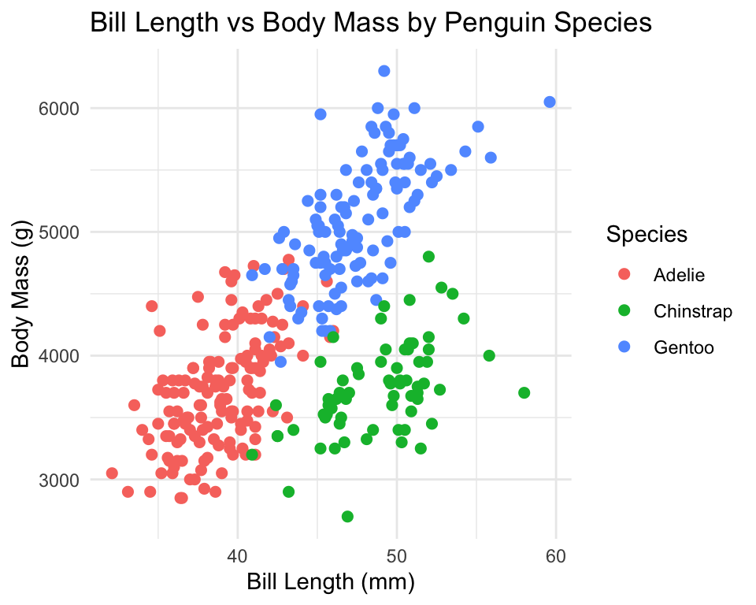

```r
# Scatter plot: Bill length vs Body mass, colored by species
ggplot(penguins_with_bmi, aes(x = bill_length, y = body_mass, color = species)) +
  geom_point(size = 2) +
  labs(
    title = "Bill Length vs Body Mass by Penguin Species",
    x = "Bill Length (mm)",
    y = "Body Mass (g)",
    color = "Species"
  ) +
  theme_minimal()
```

```r
# 5. Preview summarize
penguins_summary <- penguins_with_bmi %>%
  group_by(species) %>%
  summarize(
    avg_bill_length = mean(bill_length),
    avg_body_mass   = mean(body_mass),
    avg_bmi_index   = mean(bmi_index),
    count = n()
  )

penguins_summary
```

```
## # A tibble: 3 × 5
##   species   avg_bill_length avg_body_mass avg_bmi_index count
##   <fct>               <dbl>         <dbl>         <dbl> <int>
## 1 Adelie               38.8         3706.          19.5   146
## 2 Chinstrap            48.8         3733.          19.0    68
## 3 Gentoo               47.6         5092.          23.4   119
```

## Real data exploration

Again, find a dataset (you can reuse one from a previous assignment or lecture if you wish, but you’re encouraged to explore a new one!)

Import it in, then do the following:

- Make sure each column is properly converted into an appropriate type (if not, use a single call to mutate to convert everything).
- If there are any necessary data transforms to be done, or interesting additional variables you can derive/compute, you can also mutate that. Explain your choices if you do.
- Make some exploratory plots of the data using the NEW plot types we learned this week. Again, try to focus on a small number of most useful plots for visualizing and getting a feel for the dataset.
- Try to fine tune your plot more carefully and intentionally, in particular explore these possible modifications to your plots:
  - Faceting variables
  - Changing scales to make your plot more readable
  - Adding further annotations like trend curves/lines, horizontal/vertical lines at points of interest, etc.
  - Changing themes to something you prefer
  - If it makes sense, adding some function overlay (e.g. normal curve over an approximately normal histogram As always, briefly explain your choices.
- Briefly comment on your plots, identifying anything of interest/concern.